# Density-based Clusting using DBSCAN in R

## Description

밀도 기반 알고리즘은 **동일 군집에 속하는 데이터는 서로 근접하게 분포할 것**이라는 가정을 기반으로 한다. 본 실습에서는 밀도 기반 알고리즘으로 `DBSCAN`(Density-based spatial clustering of application with noise)알고리즘을 소개한다.

밀도 기반 군집에 대한 이론은 [밀도기반군집(density-based clustering)](https://syj9700.tistory.com/40?category=850753) 포스팅에 자세히 기록해두었으니 참고바랍니다.

- **Center-based vs Density-based**

  군집분석은 대표적인 비지도학습으로 크게 중심-기반(Center-based)알고리즘과 밀도-기반(Density-based)알고리즘으로 나눌 수 있다. 두 알고리즘의 특징에 대해 간단히 설명하면, `중심 기반 알고리즘`의 경우 중심을 기준으로 군집을 형성하기 때문에 원의 형태를 가지게 된다. 반면, `밀도 기반 알고리즘`의 경우 이웃 데이터를 기준으로 군집을 형성하기 때문에 불특정한 형태를 가지게 된다. 이 말은 즉, 데이터의 형태가 불특정한 분포의 형태를 띨때, 밀도 기반 군집을 이용하면 적절하다는 것과 같다. 또한, 지정된 밀도 안에 속하지 못해 군집에 포함되지 못한 데이터는 잡음(noise) or 이상치(outlier)로 판단할 수 있으며 이를 이용해 Anomaly detection에 활용할 수 있다. 중심-기반 알고리즘의 대표적인 방법으로는 K-means가 있다.
- **Basic Idea**

  밀도기반군집의 아이디어는 데이터를 $\epsilon$과 minPts에 따라 3개의 분류점으로 나눌 수 있으며, 분류점들의 관계를 기반으로 **코어점을 분류해 군집으로 형성**한다. (최대한 말을 풀어서 설명하였으나 더 자세하게 포스팅에 적혀있으니 참고 바랍니다.)
- **DBSCAN algorithm**
  1. $\epsilon$(반경)과 MinPts를 설정한다.
  2. 데이터로부터 코어점의 조건을 만족하는 임의의 점을 선택한다.
  3. 밀도-도달가능한 점들을 뽑아서 코어점과 경계점을 구분하고, 이에 속하지 않은 점들을 잡음으로 구분한다.
  4. $\epsilon$-반경 안에 있는 코어점들을 서로 연결한다.
  5. 연결된 코어점들을 하나의 군집으로 형성한다.
  6. 모든 경계점들은 어느 하나의 군집에 할당한다. (여러 군집에 걸쳐있는 경우, 반복 과정에서 먼저 할당된 군집으로 할당)

## Data

```r
library(factoextra)
data(multishapes)
summary(multishapes)
```

```
##        x                  y               shape
##  Min.   :-1.48918   Min.   :-3.3535   Min.   :1.000
##  1st Qu.:-0.47884   1st Qu.:-1.1268   1st Qu.:1.000
##  Median :-0.13292   Median :-0.2970   Median :2.000
##  Mean   :-0.08122   Mean   :-0.6254   Mean   :2.227
##  3rd Qu.: 0.36607   3rd Qu.: 0.2508   3rd Qu.:3.000
##  Max.   : 1.49221   Max.   : 1.2539   Max.   :6.000
```

- multishapes{factoextra}는 3개의 변수와 1100개의 관측값으로 이루어진 자료이다. DBSCAN 알고리즘을 이용한 밀도기반의 군집분석을 수행할 것이다.

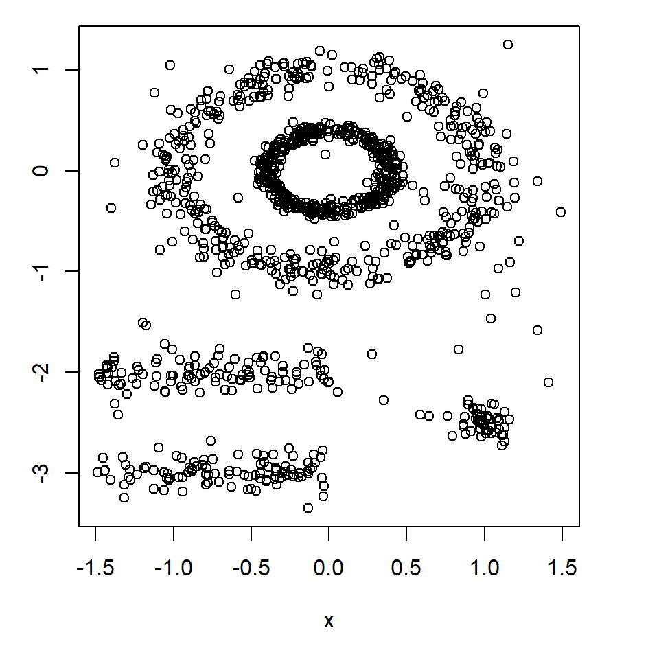

```r
par(mar=c(4, 2, 0, 2), # inner margin
    oma=c(1, 1, 1, 1)) #outer margin
plot(multishapes[,1:2])
```

- 데이터의 분포를 보면 불특정분포의 형태를 띠고 있으며, 5개 정도의 군집으로 이루어졌음을 예상할 수 있다.

## DBSCAN

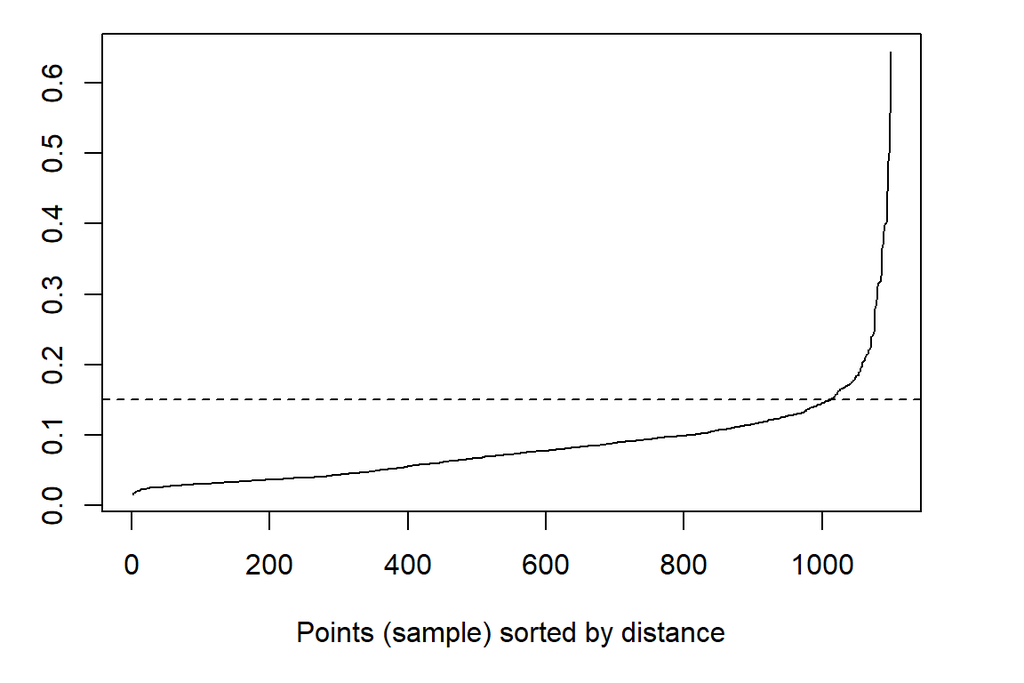

```r
par(mar=c(4, 2, 0, 2), # inner margin
    oma=c(1, 1, 1, 1)) #outer margin

library(dbscan)
kNNdistplot(multishapes[,1:2], k=5) #k : minPoints
abline(h = 0.15, lty=2)
```

- kNNdistplot 함수는 군집을 형성하는데 필요한 최소의 데이터 수(minPoints, 옵션명:k)를 지정해주면, 군집을 형성할 때 최적의 분류를 수행하도록 해주는 반경($\epsilon$)을 결정하도록 도와준다.
- 인접이웃의 수(k)를 5로 설정하여 k-거리를 구한 결과, $\epsilon=0.15$에서 경사가 급해지므로, 반경이 0.15일때 군집간 분리가 가장 잘 되며 그 이후로는 군집 내의 거리가 지수적으로 커지므로 군집이 잘 분리될 것이라고 예상할 수 없다.

```r
library(fpc)
db_clust <- dbscan(multishapes[,1:2], eps = 0.15, MinPts = 5)
print(db_clust)
```

```
## dbscan Pts=1100 MinPts=5 eps=0.15
##         0   1   2   3  4  5
## border 31  24   1   5  7  1
## seed    0 386 404  99 92 50
## total  31 410 405 104 99 51
```

- 1100개 객체에 대하여 DBSCAN 수행결과, 5개의 군집으로 분류되며, 31개의 잡음점이 발생하였다.
- border는 경계점, seed는 코어점을 의미하며, 잡음점은 0으로 처리되었다.

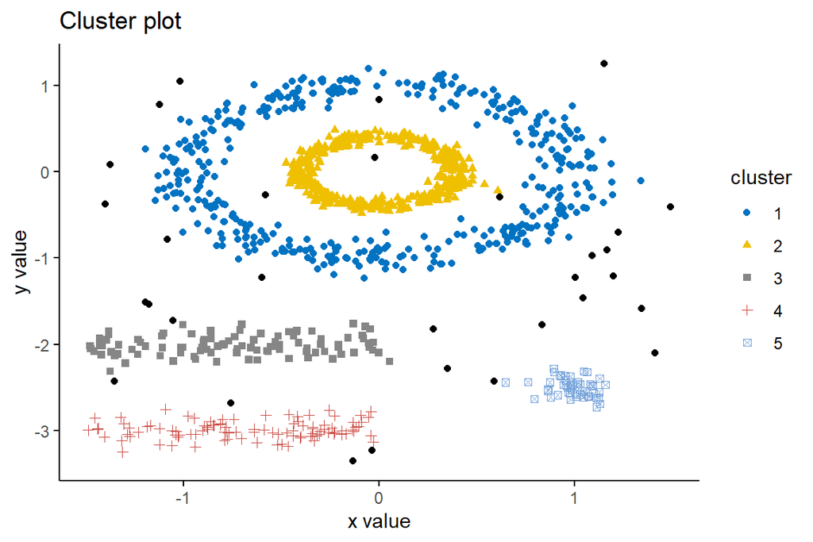

```r
par(mar=c(4, 2, 0, 2), # inner margin
    oma=c(1, 1, 1, 1)) #outer margin

fviz_cluster(db_clust, data = multishapes[,1:2], stand = FALSE, ellipse = FALSE, show.clust.cent = FALSE, geom = "point", palette = "jco", ggtheme = theme_classic())
```

- 군집분석 결과를 시각화한 것으로, 5개의 군집이 색상별로 나타나있고 검은색의 점은 잡음점을 의미한다.

## K-means vs DBSCAN

```r
mul_km <- kmeans(multishapes[,1:2], 5)
mul_km$size
```

```
## [1] 237 186 189 223 265
```

```r
mul_km$centers
```

```
##            x          y
## 1 -0.3857225 -0.4990442
## 2  0.4996849  0.4073454
## 3  0.5459273 -0.4689764
## 4 -0.4346204  0.4534263
## 5 -0.3665243 -2.4828103
```

- 초기 군집 수를 5로 지정하여 K-means를 수행하면 각 군집의 크기와 중심값을 얻을 수 있다.

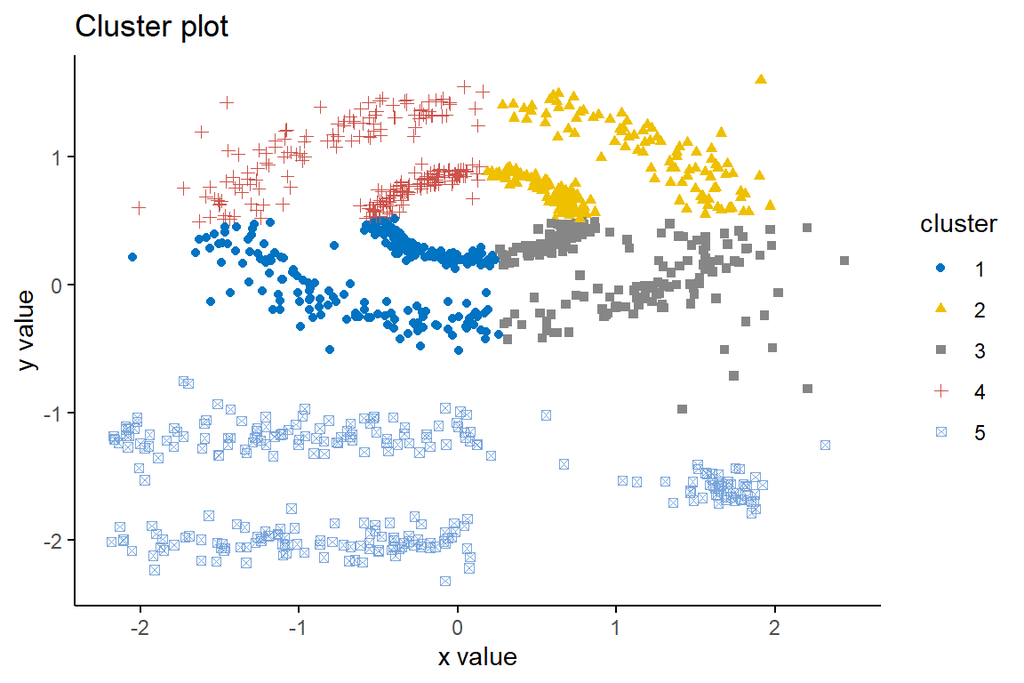

```r
par(mar=c(4, 2, 0, 2), # inner margin
    oma=c(1, 1, 1, 1)) #outer margin

fviz_cluster(mul_km, multishapes[,1:2], geom = "point", ellipse= FALSE, show.clust.cent = FALSE, palette = "jco", ggtheme = theme_classic())
```

- K-means(k=5)의 결과를 시각화 한 것으로 밀도-기반 알고리즘에 비해 효과적으로 군집을 형성하지 못함을 알 수 있다.
- K-means는 생성할 군집의 수를 지정해주어야 하지만, **DBSCAN은 군집의 수를 지정해주지 않아도 된다.** 또한, 서론에서 말했듯이 K-means는 평균 기반 알고리즘으로 군집이 원의 형태를 가지게 되지만, DBSCAN의 경우, 불특정한 형태의 군집을 형성할 수 있다. K-means알고리즘은 평균을 취하기 때문에 이상치에 민감하며, **DBSCAN은 잡음점을 식별하므로 이상치에 민감하지 않다는 장점이 있다(robust)**.